# How much does it cost to survive?

Exploring the prices of a basic food basket in Germany, Colombia and Peru

Jasmin Huynh, Carolina Cornejo, Juan D Mendez

2023-03-15

# Load packages

```r
library(RSelenium)
library(xml2)
library(magrittr)
library(lubridate)
library(tidyverse)
library(httr)
library(rvest)
library(readr)
library(XML)
library(ggplot2)
```

# Set user-agent

```r
# Please change user agent before running the code
set_config(
  user_agent("Mozilla/5.0 (Windows NT 10.0; Win64; x64) AppleWebKit/537.36 (KHTML, like Gecko) Chrome/111.0.0.0 Safari/537.36 Edg/111.0.1661.41; Carolina Cornejo / gcornejoc@putlook.com")
)
```

## Create URL-lists to scrape from

# Create vector containing all links

We use vectors containing lists of product names to create URLs. The URLs lead to the search sites, meaning the URL that is created when using the search bar of the online-shop to search for a specific product. As we try to scrape a german, colombian and peruvian shop, the product lists are in german and spanish language. Later the product lists will also be used to clean the results from scraping.

```r
# Create product list and links for german shop
products_de <- URLencode(
            c("Brot",
              "Mehl",
              "Milch",
              "Käse",
              "Eier",
              "Äpfel",
              "Orangen",
              "Bananen",
              "Tomaten",
              "Knoblauch",
              "Linsen",
              "Bohnen",
              "Kartoffeln",
              "Haferflocken",
              "Reis",
              "Zucker",
              "Nüsse",
              "Salz",
              "Rindfleisch",
              "Thunfisch",
              "Schwein",
              "Sonnenblumenöl",
              "Bandnudeln"))

links_de <- paste0(
  "https://seidl-kulmbach.edeka.shop/index.php?stoken=7DC8E5C2&lang=0&cl=search&searchparam=",
  products_de)

# Create product list and links for colombian shop

products_co <- URLencode(
  c(
  "Pan Tajado",
  "Harina",
  "Leche",
  "Queso ",
  "Huevo rojo",
  "Manzana",
  "Mandarina Comun",
  "Platano",
  "tomate",
  "ajo",
  "Lentejas",
  "Frijol",
  "Papas",
  "Avena",
  "Arroz",
  "Azucar Blanca",
  "Nueces",
  "Sal marina",
  "Carne",
  "Atun",
  "Pollo",
  "Aceite Vegetal",
  "Fideos"
))

links_co <- paste0(
  "https://www.exito.com/",
  products_co, "?_q=", products_co, "&map=ft")

# Create product list and links for peruvian shop

products_pe <- URLencode(
  c(
  "pan",
  "harina",
  "leche",
  "queso",
  "huevos",
  "papaya",
  "fresa",
  "plátano",
  "tomate",
  "ajo molido",
  "lenteja",
  "frijol",
  "papa",
  "avena",
  "arroz",
  "azúcar",
  "nueces",
  "sal marina",
  "carne de res",
  "atún en aceite",
  "pollo",
  "aceite",
  "fideo"
))

links_pe <- paste0(
  "https://www.metro.pe/busca/?ft=",
  products_pe)
```

# Create vector in English containing all product names

This only serves informational purpose.

```r
products <- c("bread",
  "flour",
  "milk",
  "cheese",
  "eggs",
  "apples",
  "oranges",
  "bananas",
  "tomatoes",
  "garlic",
  "lentils",
  "beans",
  "potatoes",
  "oatmeal",
  "rice",
  "sugar",
  "nuts",
  "salt",
  "beef",
  "tuna",
  "pork",
  "oil",
  "noodles")
```

# Combine vectors to a dataframe for every country

```r
all_links_de <- data.frame(links_de, products, URLdecode(products_de)) %>% rename(products_de=URLdecode.products_de.)
all_links_co <- data.frame(links_co, products, URLdecode(products_co)) %>% rename(products_co=URLdecode.products_co.)
all_links_pe <- data.frame(links_pe, products, URLdecode(products_pe)) %>% rename(products_pe=URLdecode.products_pe.)

# Remove vectors
#rm(links_de, links_col, links_peru, products)
```

# Create an empty dataframe to store the scraped results for each country

```r
basic_de <- data.frame(
  names = character(),
  prices = numeric(),
  prices_per_kg_l = numeric()
)

basic_co <- data.frame(
  names = character(),
  prices = numeric(),
  prices_per_kg_l = numeric()
)

basic_pe <- data.frame(
  names = character(),
  prices = numeric(),
  prices_per_kg_l = numeric()
)
```

# Define a function to extract data from a single URL for every website

For each webshop a function is defined. All three function use a URL and a product name in german or spanish as input. First the function for the german webshop is explained:

The function “extract_data_de” first extracts the html-code from the URL and stores it in ‘html_code’. Then the following steps are applied using this html-code: 1. Extract product names: A XPath is used to extract the names of all products which appear on the website when searching for the product. The extracted text is cleaned and whitespaces are trimmed. 2. Extract product prices: A XPath is used to extract the corresponding prices of all products which appear on the website. The extracted prices are cleaned and whitespaces are removed with str_trim() and str_squish(). The strings are converted to numbers. 3. Extract price per kilogramm or liter: A XPath is used to extract the corresponding prices per kg/l. The extracted prices are cleaned and whitespaces are removed with str_trim() and str_squish(). The strings are converted to numbers. 4. The extracted information is combined into a dataframe ‘product_table’ which contains the extracted information of the search results from a single URL. 5. As the listed search results also contain products which are not the searched products the table gets cleaned. This is achieved by using grepl() to only keep the rows where the product names contain a specific string, The string that is used is the product name that is used as input for the function. 6. Finally only the cheapest product of the product table according to price per kilogramm or liter is kept and returned.

```r
# Germany

extract_data_de <- function(url, product) {

  # Read html
  html_code <- read_html(url)

  # Extract product names
  names <- html_code %>%
    html_nodes(xpath = "//div[@class='listDetails']//a") %>%
    html_text() %>%
    str_replace_all("\\t|\\n", "") %>%
    str_trim()

  # Extract product prices
  prices <- html_code %>%
    html_nodes(xpath = "//div[@class='listDetails']//div[@class='article-price']") %>%
    html_text() %>%
    str_replace_all("\\n|\\*|€", "") %>%
    str_trim() %>%
    str_squish() %>%
    readr::parse_number(., locale = readr::locale(decimal_mark = ","))

  # Extract price per kilogramm or liter
  prices_per_kg_l <- html_code %>%
    html_nodes(xpath = "//div[@class='listDetails']//div[@class='pricePerUnit']") %>%
    html_text() %>%
    str_replace_all("\\n|/kg|€", "") %>%
    str_trim() %>%
    str_squish() %>%
    readr::parse_number(., locale = readr::locale(decimal_mark = ","))

  # Combine everything into a dataframe
  product_table <- data.frame(names, prices, prices_per_kg_l)

  # Clean out everything that is not the searched product
  product_table <- product_table[grepl(product, product_table$names,
  ignore.case = TRUE),]
  rownames(product_table) <- NULL

  # Keep only the cheapest product according to price per kilogramm or liter
  final <- product_table[which.min(product_table$prices_per_kg_l),]

  return(final)
}
```

The colombian scraper quite works the same as the german with some added steps as some of the listed products contain a price per mg/ml and some don’t. Also the price per mg/ml gets converted to price per kg/l. The final prices are converted to Euros.

```r
# Colombia

# Run Selenium Server

remDr <- rsDriver(port = 4568L,
                   version = "latest",
                   browser=c("chrome"),
                   chromever = "110.0.5481.77",
                   phantomver = "2.1.1",
                   verbose = TRUE,
                   check = TRUE)
```

[output not shown]

[output not shown]

[output not shown]

[output not shown]

[output not shown]

[output not shown]

[output not shown]

[output not shown]

[output not shown]

[output not shown]

[output not shown]

[output not shown]

[output not shown]

[output not shown]

[output not shown]

[output not shown]

[output not shown]

[output cut: 14 more lines]

[output not shown]

```r
driver <- remDr$client

extract_data_co <- function(url, product) {

# Using Selenium to close popup, and using sys.sleep to make sure that webpage is fully loaded.

Sys.sleep(5)
driver$navigate(url)
Sys.sleep(12)
button1 <- driver$findElement(using = "css selector", value = ".exito-geolocation-3-x-cursorPointer")
button1$clickElement()
Sys.sleep(1)
page_source <- driver$getPageSource()[[1]]

# Extract product names

  names <- page_source %>%
    read_html() %>%
    xml_find_all("//h3[@class='vtex-store-components-3-x-productNameContainer mv0 t-heading-4']//span") %>%
  xml_text()

  # Extract product prices.Prices where in different formats.

  prices <- page_source %>%
  read_html() %>%
  xml_find_all("//div[@class='exito-vtex-components-4-x-PricePDP']//text()") %>%
  html_text() %>%
    # first extract all numbers
  str_extract_all("\\d+") %>%
  lapply(paste, collapse = "") %>%
  unlist() %>%
    # then extract only first numbers to avoid decimals.
  sub("(^\\d{4}).*", "\\1", .) %>%
  readr::parse_number(locale = readr::locale(decimal_mark = ","))


# Extract price per kilo. In this case, some of values per kilo were missed. For that purpose we made a loop to check if a child div was inside a parent divs. If so, extract the number, but if not, impute a Zero.

parent_divs <- html_nodes(read_html(page_source), xpath = "//div[@class='flex mt0 mb0 pt0 pb0    justify-start vtex-flex-layout-0-x-flexRowContent vtex-flex-layout-0-x-flexRowContent--product-info-element items-stretch w-100']")

# create an empty vector to store the extracted strings
extracted_strings <- c()

# loop over each parent div and check for the desired child div
for (i in 1:length(parent_divs)) {

  # check if the desired div is present inside the current parent div
  if (length(html_nodes(parent_divs[i], xpath = ".//div[@class='exito-vtex-components-4-x-validatePumValue f6 fw1 tl']")) > 0) {

    # if it is, extract the string and append it to the vector
extracted_strings <- c(extracted_strings, html_text(html_nodes(parent_divs[i], xpath = ".//div[@class='exito-vtex-components-4-x-validatePumValue f6 fw1 tl']")))

  } else {

    # if it's not, append 0 to the vector
    extracted_strings <- c(extracted_strings, 0)

  }

}

# Extract the number of price per grams
prices_per_kg_l <- extracted_strings %>%
  str_extract_all("\\d+(?:,\\d+)?(?:\\.\\d+)?") %>% unlist() %>%
  readr::parse_number(., locale = readr::locale(decimal_mark = ","))


  # Combine everything in one dataframe, removing the values in 0 for prices per grams, transforming grams into Kilogramms, and making the change from Colombian pesos to Euros
  product_table <- data.frame(names, prices, prices_per_kg_l) %>%
  filter(!prices_per_kg_l == 0.00) %>%
  mutate(prices_per_kg_l = prices_per_kg_l * 1000) %>%
  mutate(prices_per_kg_l = prices_per_kg_l / 5000,
         prices = prices/ 5000)

  # Clean out everything that is not the searched product
  product_table <- product_table[grepl(product, product_table$names, ignore.case = TRUE),]
  rownames(product_table) <- NULL

  # Keep only the cheapest product according to price per kilo
  final <- product_table[which.min(product_table$prices_per_kg_l),]

  return(final)
}
```

The peruvian scraper quite works the same as the german with some added steps to standardize the prices as the webshop doesn’t contain one standardize price (e.g. price per kg/l) for the listed products.

```r
# Peru
extract_data_pe <- function(url, product) {
  product_names <- url %>%
    read_html() %>%
    html_nodes(xpath = "//div[@class='product-item__info']//a") %>%
    html_text()

  names <- product_names %>%
    str_extract("[^\\d\\n].*?(?=\\d)") %>%
    str_trim()

  quantities <- product_names %>%
    str_extract("\\d+(\\.\\d+)?") %>%
    as.numeric()

  units <- product_names %>%
    str_replace(names, "") %>%
    str_extract("\\s*[a-zA-Z]+") %>%
    str_trim()

  prices <- url %>%
      read_html() %>%
      html_nodes(".product-prices__value--best-price") %>%
      html_text() %>%
      str_extract("\\d+\\.\\d+") %>%
      as.numeric()

  # Combine everything into a dataframe
  product_table_peru <- data.frame(names, quantities, units, prices)


  rm(product_names)

  # Clean out everything that is not the searched product
  product_table_peru <- product_table_peru[grepl(product,
                                            product_table_peru$names,
                                            ignore.case = TRUE
                                            ), ]

  rownames(product_table_peru) <- NULL

  # Create the prices per kilo or liter column
product_table_peru$prices_per_kg_l <- ifelse(product_table_peru$units == "un", product_table_peru$prices,
                                                ifelse(product_table_peru$units == "g", product_table_peru$prices / product_table_peru$quantities * 1000,
                                                       ifelse(product_table_peru$units == "ml", product_table_peru$prices / product_table_peru$quantities * 1000,
                                                              ifelse(product_table_peru$units == "kg" & product_table_peru$quantities == 1, product_table_peru$prices,
                                                                     NA
                                                              )
                                                       )
                                                )
)

  # Keep only the cheapest product according to price per kilo/litro
final_peru <- product_table_peru[which.min(product_table_peru$prices_per_kg_l),]

return(final_peru)
}
```

# Use lapply to extract data from all URLs

To apply the extracting functions to all URLs ‘laaply()’ is used to loop over the dataframes. The columns which contain the URLs and the corresponding product names in german or spanish are passed as input to the functions.

```r
basic_list_de <- lapply(seq_len(nrow(all_links_de)), function(i) {
  extract_data_de(all_links_de$links[i], all_links_de$products_de[i])
})

basic_list_co <- lapply(seq_len(nrow(all_links_co)), function(i) {
  extract_data_co(all_links_co$links[i], all_links_co$products_co[i])
})

basic_list_pe <- lapply(seq_len(nrow(all_links_pe)), function(i) {
  extract_data_pe(all_links_pe$links[i], all_links_pe$products_pe[i])
})

# Close browser and server

driver$close()
remDr$server$stop()
```

```
## [1] TRUE
```

```r
# clean up
gc()
```

```
##           used (Mb) gc trigger  (Mb) max used  (Mb)
## Ncells 1382949 73.9    2473314 132.1  2473314 132.1
## Vcells 2295171 17.6   10146329  77.5 10097898  77.1
```

# Combine results into data frame

```r
basic_de <- do.call(rbind, basic_list_de)
rownames(basic_de) <- NULL   # reset index of dataframe

basic_co <- do.call(rbind, basic_list_co)
rownames(basic_co) <- NULL # reset index of dataframe

basic_pe <- do.call(rbind, basic_list_pe)
rownames(basic_pe) <- NULL # reset index of dataframe

# Change from "soles" to "euros for the peruvian prices
basic_pe$prices <- round(basic_pe$prices*0.25, 2)
```

# How much is the approximate amount that a citizen spends for basic necessities in Germany, Colombia and Peru compared to the minimum living wage?

The wages per week are from Wikipedia: https://en.wikipedia.org/wiki/List_of_countries_by_minimum_wage

```r
# Create a data frame containing the information for each country

df_countries <- data.frame(
  country = c("germany", "colombia", "perú"),
  total = c(sum(basic_de$prices), sum(as.numeric(basic_co$prices)), sum(basic_pe$prices)),
  minimum_wage_wk = c(528.42, 69.26, 69.26)
)

df_countries$prop <- df_countries$total/df_countries$minimum_wage_wk
```

# Plot the results

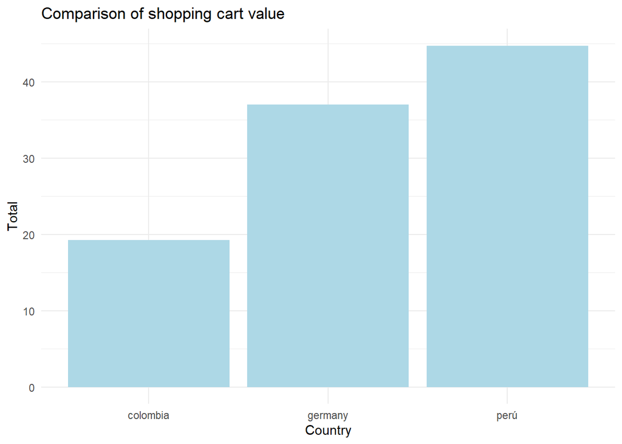

```r
# Create the plot
ggplot(df_countries, aes(x = country, y = total)) +
  geom_bar(stat = "identity", fill = "lightblue") +
  labs(x = "Country", y = "Total", title = "Comparison of shopping cart value") +
  theme_minimal()
```

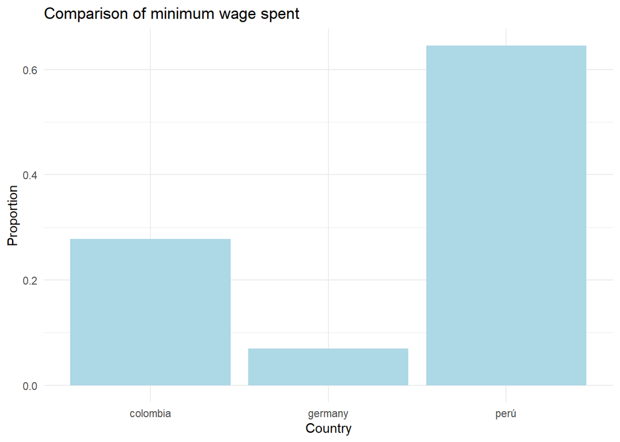

```r
ggplot(df_countries, aes(x = country, y = prop)) +
  geom_bar(stat = "identity", fill = "lightblue") +
  labs(x = "Country", y = "Proportion", title = "Comparison of minimum wage spent") +
  theme_minimal()
```

As can be seen, taking as a reference the prices in Euros, there are notorious differences in the amount spent by citizens in these countries. The country that spends the least is Colombia, followed by Germany, and followed by Peru.

However, then considering the weekly minimum wage of each country, the proportion varies. Peru is the country in which people spends the most, in a general sense but also as a proportion of their mimimum age. On the other hand, Germany is the country that spends the least in comparison with their minimum wage.